# Ecrire aux député.e.s concerné.e.s par le loup

Olivier Gimenez

18/11/2021

## Motivation

Il y a un débat sur le nombre de loups en France. Pour contribuer à informer, j’ai rédigé une note (ou “policy brief”) sur la méthode de comptage de loups. Je me suis dit pourquoi pas envoyer ces informations aux député.e.s concerné.e.s par le loup. J’entends par là les départements où le loup est présent. Pour ce faire, j’ai besoin d’une liste de noms des député.e.s avec leur emails, seulement pour les départements où le loup est présent.

## Pré-requis

Quelques packages utiles.

```r
library(tidyverse)
theme_set(theme_light(base_size = 12))
library(janitor)
library(downloader)
library(sf)
```

## Les députés

Toutes les données sont sur le site https://data.assemblee-nationale.fr/acteurs/deputes-en-exercice, mais nécessitent un petit traitement pour créer une liste.

Je suis paresseux, et je vais passer par le site https://www.voxpublic.org/ qui “met à la disposition des acteurs citoyens des savoir-faire dans leurs actions d’interpellation des décideurs publics”. Leur section https://www.voxpublic.org/-Centre-de-ressources-.html est riche en informations précieuses. Il y a en particulier plusieurs annuaires partagés, dont un pour les députés.

On précise le chemin vers le fichier à télécharger.

```r
path <- "https://www.voxpublic.org/IMG/csv/fichier_deputes_commissions.csv"
```

On télécharge le fichier depuis le site voxpublic.org.

```r
download(url = path, destfile = "dat/deputes.csv", mode = "wb")
```

On lit le fichier.

```r
deputes <- read_csv("dat/deputes.csv")
deputes
```

```
## # A tibble: 570 × 16
##    nom     sexe  num_deptmt nom_circo num_circo groupe_sigle commission_permane…
##    <chr>   <chr> <chr>      <chr>         <dbl> <chr>        <chr>
##  1 Jean-M… H     86         Vienne            3 LT           Affaires étrangères
##  2 Bernar… H     13         Bouches-…        15 LR           Défense nationale …
##  3 Charle… H     51         Marne             5 LT           Finances de l’écon…
##  4 Jean-L… H     69         Rhône             3 LREM         Affaires sociales
##  5 Marc L… H     22         Côtes-d'…         3 LR           Finances de l’écon…
##  6 Franço… H     44         Loire-At…         1 LREM         Défense nationale …
##  7 Jérôme… H     16         Charente          3 SOC          Affaires étrangères
##  8 Gérard… H     88         Vosges            2 LR           Affaires sociales
##  9 Franço… H     52         Haute-Ma…         2 LR           Finances de l’écon…
## 10 Éric C… H     06         Alpes-Ma…         1 LR           Lois
## # … with 560 more rows, and 9 more variables: fonction <chr>, sites_web <chr>,
## #   emails <chr>, twitter <chr>, autres_mandats <chr>, tel <chr>,
## #   adresse_permanence <chr>, cp_permanence <chr>, ville_permanence <chr>
```

## Le loup

Où est le loup? On télécharge la carte de présence du loup en France en 2019 depuis le site officiel http://carmen.carmencarto.fr/38/Loup.map.

```r
loup <- st_read("dat/loup_2019_maille_L93.shp")
```

On jette un coup d’oeil.

```r
glimpse(loup)
```

```
## Rows: 644
## Columns: 10
## $ ID       <int> 231975, 232645, 232646, 232647, 232648, 233317, 233987, 24138…
## $ CD_SIG   <chr> "10kmE346N225", "10kmE347N225", "10kmE347N226", "10kmE347N227…
## $ PRESENCE <chr> "Occasionnelle", "Occasionnelle", "Occasionnelle", "Occasionn…
## $ ANNEE    <int> 2019, 2019, 2019, 2019, 2019, 2019, 2019, 2019, 2019, 2019, 2…
## $ DATE_MIN <chr> "01/04/2016", "01/04/2016", "01/04/2016", "01/04/2016", "01/0…
## $ DATE_MAX <chr> "31/03/2019", "31/03/2019", "31/03/2019", "31/03/2019", "31/0…
## $ X        <dbl> 415208.8, 425169.5, 424307.6, 423444.3, 422579.8, 433403.6, 4…
## $ Y        <dbl> 6202309, 6203266, 6213243, 6223218, 6233192, 6224176, 6225132…
## $ ESPECE   <chr> "Loup gris", "Loup gris", "Loup gris", "Loup gris", "Loup gri…
## $ geometry <POLYGON [m]> POLYGON ((420619.8 6197799,..., POLYGON ((430580.4 61…
```

En détail.

```r
loup
```

```
## Simple feature collection with 644 features and 9 fields
## Geometry type: POLYGON
## Dimension:     XY
## Bounding box:  xmin: 409798 ymin: 6135908 xmax: 1080900 ymax: 7010784
## Projected CRS: RGF93 / Lambert-93
## First 10 features:
##        ID       CD_SIG      PRESENCE ANNEE   DATE_MIN   DATE_MAX        X
## 1  231975 10kmE346N225 Occasionnelle  2019 01/04/2016 31/03/2019 415208.8
## 2  232645 10kmE347N225 Occasionnelle  2019 01/04/2016 31/03/2019 425169.5
## 3  232646 10kmE347N226 Occasionnelle  2019 01/04/2016 31/03/2019 424307.6
## 4  232647 10kmE347N227 Occasionnelle  2019 01/04/2016 31/03/2019 423444.3
## 5  232648 10kmE347N228 Occasionnelle  2019 01/04/2016 31/03/2019 422579.8
## 6  233317 10kmE348N227 Occasionnelle  2019 01/04/2016 31/03/2019 433403.6
## 7  233987 10kmE349N227 Occasionnelle  2019 01/04/2016 31/03/2019 443362.3
## 8  241383 10kmE360N253 Occasionnelle  2019 01/04/2016 31/03/2019 529903.0
## 9  244029 10kmE364N219     Régulière  2019 01/04/2016 31/03/2019 599608.7
## 10 244698 10kmE365N218 Occasionnelle  2019 01/04/2016 31/03/2019 610424.6
##          Y    ESPECE                       geometry
## 1  6202309 Loup gris POLYGON ((420619.8 6197799,...
## 2  6203266 Loup gris POLYGON ((430580.4 6198756,...
## 3  6213243 Loup gris POLYGON ((429718.9 6208734,...
## 4  6223218 Loup gris POLYGON ((428856.1 6218710,...
## 5  6233192 Loup gris POLYGON ((427992 6228685, 4...
## 6  6224176 Loup gris POLYGON ((438815.3 6219667,...
## 7  6225132 Loup gris POLYGON ((448774 6220622, 4...
## 8  6494609 Loup gris POLYGON ((535327.1 6490113,...
## 9  6159486 Loup gris POLYGON ((605016.9 6154960,...
## 10 6150433 Loup gris POLYGON ((615832.5 6145905,...
```

On a aussi besoin d’une carte de France.

```r
france <- st_read('dat/departements.shp') %>%
  clean_names() %>%
  transmute(num_departement = d_p_artem,
            nom_departement = str_to_lower(d_p_art_1),
            num_region = r_g_ion,
            nom_region = str_to_lower(nom_r_g_i))
```

Combien de carrés où le loup est présent?

```r
loup %>%
  as_tibble() %>%
  group_by(ANNEE, PRESENCE) %>%
  summarise(count = n())
```

```
## # A tibble: 2 × 3
## # Groups:   ANNEE [1]
##   ANNEE PRESENCE      count
##   <int> <chr>         <int>
## 1  2019 Occasionnelle   260
## 2  2019 Régulière       384
```

On représente la présence du loup en 2019 sur une carte.

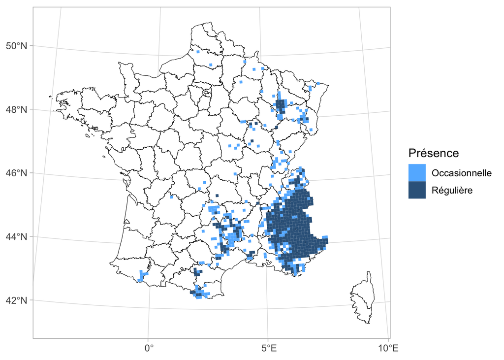

```r
loup %>%
    ggplot() +
    geom_sf(data = france,
            colour = "black",
            fill = "white",
            lwd = 0.2) +
    geom_sf(aes(fill = PRESENCE), lwd = 0) +
    scale_fill_manual(values = c('steelblue1','steelblue4'),
                      name = "Présence",
                      labels = c("Occasionnelle", "Régulière"))
```

## Quels sont les départements où le loup est présent?

Quels sont les départements où le loup est présent?

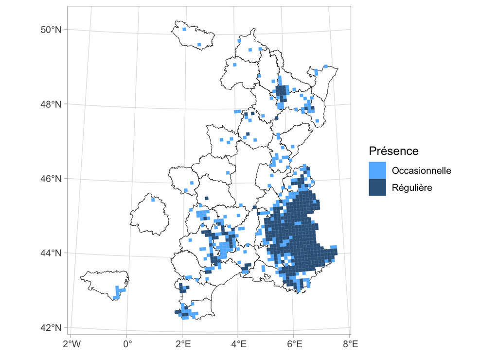

```r
pres_par_dptmt <- st_contains(france, loup)
ou_loup <- sapply(pres_par_dptmt, length) > 0
num_dptment_loup <- france$num_departement[ou_loup]
nom_dptment_loup <- france$nom_departement[ou_loup]

loup %>%
    ggplot() +
    geom_sf(data = france[ou_loup,],
            colour = "black",
            fill = "white",
            lwd = 0.2) +
    geom_sf(aes(fill = PRESENCE), lwd = 0) +
    scale_fill_manual(values = c('steelblue1','steelblue4'),
                      name = "Présence",
                      labels = c("Occasionnelle", "Régulière"))
```

## Députés, départements et loups

Quels sont les députés dont les départements ont vu la présence du loup en 2019 (régulière ou occasionnelle) ?

```r
deputes_loup <- deputes %>%
  filter(num_deptmt %in% num_dptment_loup)
deputes_loup
```

```
## # A tibble: 182 × 16
##    nom     sexe  num_deptmt nom_circo num_circo groupe_sigle commission_permane…
##    <chr>   <chr> <chr>      <chr>         <dbl> <chr>        <chr>
##  1 Bernar… H     13         Bouches-…        15 LR           Défense nationale …
##  2 Charle… H     51         Marne             5 LT           Finances de l’écon…
##  3 Gérard… H     88         Vosges            2 LR           Affaires sociales
##  4 Franço… H     52         Haute-Ma…         2 LR           Finances de l’écon…
##  5 Éric C… H     06         Alpes-Ma…         1 LR           Lois
##  6 Jean-C… H     84         Vaucluse          2 LR           Affaires étrangères
##  7 Jean-L… H     68         Haut-Rhin         3 LR           Affaires étrangères
##  8 Michèl… F     06         Alpes-Ma…         9 LR           Affaires étrangères
##  9 Bertra… H     55         Meuse             1 LT           Affaires culturell…
## 10 Béreng… F     08         Ardennes          1 LR           Affaires étrangères
## # … with 172 more rows, and 9 more variables: fonction <chr>, sites_web <chr>,
## #   emails <chr>, twitter <chr>, autres_mandats <chr>, tel <chr>,
## #   adresse_permanence <chr>, cp_permanence <chr>, ville_permanence <chr>
```

On met les députés dans un fichier, et les députées dans un autre.

```r
deputes_loup %>%
  filter(sexe == "H") %>%
  select(nom, emails) %>%
  separate(emails, c("email1", "email2"), sep = "([|])") %>%
  write_csv(file = "dat/deputes_loups.csv")

deputes_loup %>%
  filter(sexe == "F") %>%
  select(nom, emails) %>%
  separate(emails, c("email1", "email2"), sep = "([|])") %>%
  write_csv(file = "dat/deputees_loups.csv")
```

## Courriel

On a approx 80 députées et 100 députés dont le département est concerné par le loup. Pour faire un envoi groupé, j’ai créé un groupe pour les députés et un autre pour les députées dans le petit logiciel `Contacts` (je suis sous Mac), puis j’ai envoyé un message à M. le Député, et un autre à Mme la Députée avec l’application mail `Spark` que j’adore.

Voici le message :

La réduction des dommages causés par le loup sur les troupeaux domestiques est une priorité du [plan national d’actions 2018-2023 sur le loup et les activités d’élevage](https://www.ecologie.gouv.fr/sites/default/files/PNA_Loup-et-activites-elevage_2018-2023.pdf). L’Etat autorise un [contrôle létal au travers de prélèvements dérogatoires](https://hal.archives-ouvertes.fr/hal-02992939/document) indexés sur le nombre de loups. Alors que le nombre de loups fait débat, il m’a semblé important d’informer sur la manière dont les loups sont comptés en France.

Dans une note d’information (ou “policy brief”) que je souhaite partager avec vous, je reviens sur la méthode scientifique utilisée, fruit de 15 ans de collaborations entre le Centre National de la Recherche Scientifique (CNRS) et l’Office Français de la Biodiversité (OFB). Le loup étant présent dans votre département (selon les données 2019 de l’OFB), ces informations vous seront peut-être utiles.

La note au format PDF est téléchargeable ici https://bit.ly/3qMGYB5, et se trouve également en ligne là https://bit.ly/3Cqq7Gv.

Cordialement, Olivier Gimenez, directeur de recherche au CNRS.